# Stats_Project_2022_Fall_Group_B

Marina, Paul, Thomas

2022-12-06

# 1. Data Cleaning

Data can be found in the same directory as this report. If it is unusable, it was originally downloaded from:

https://journals.plos.org/plosone/article/file?type=supplementary&id=10.1371/journal.pone.0107276.s002

```r
df<-read_excel('Table_S2.xls')
head(df)
```

```
## # A tibble: 6 × 32
##   Supplement…¹ ...2  ...3  ...4  ...5  ...6  ...7  ...8  ...9  ...10 ...11 ...12
##   <chr>        <chr> <chr> <chr> <chr> <chr> <chr> <chr> <chr> <chr> <chr> <chr>
## 1 ID           tumo… Sex   Age   Smok… path  Ope … T     N     Stag… hTERT EGFR…
## 2 <NA>         <NA>  <NA>  <NA>  <NA>  <NA>  <NA>  <NA>  <NA>  <NA>  <NA>  <NA>
## 3 <NA>         <NA>  <NA>  <NA>  <NA>  <NA>  <NA>  <NA>  <NA>  <NA>  <NA>  <NA>
## 4 <NA>         <NA>  <NA>  <NA>  <NA>  <NA>  <NA>  <NA>  <NA>  <NA>  <NA>  <NA>
## 5 <NA>         <NA>  <NA>  <NA>  <NA>  <NA>  <NA>  <NA>  <NA>  <NA>  <NA>  <NA>
## 6 <NA>         <NA>  <NA>  <NA>  <NA>  <NA>  <NA>  <NA>  <NA>  <NA>  <NA>  <NA>
## # … with 20 more variables: ...13 <chr>, ...14 <chr>, ...15 <chr>, ...16 <chr>,
## #   ...17 <chr>, ...18 <chr>, ...19 <chr>, ...20 <chr>, ...21 <chr>,
## #   ...22 <chr>, ...23 <chr>, ...24 <chr>, ...25 <chr>, ...26 <chr>,
## #   ...27 <chr>, ...28 <chr>, ...29 <chr>, ...30 <chr>, ...31 <chr>,
## #   ...32 <lgl>, and abbreviated variable name
## #   ¹`Supplementary Table 2.Mutational and survival information of 174 NSCLC patients.`
```

First, we’re going to fix the formatting and column names. The column names have been read into the first row, with the table title as the first column name.

We’re also going to rename a few of the columns for clarity, and to avoid syntax issues.

```r
if(colnames(df[,2])=='...2'){
  colnames(df)<-gsub(" ","_",subset(df,df[,1]=='ID'))
}

df<-rename(df,c('tumor_rate_percent'='tumor_rate_%',
                'T_of_tumor'='T',
                'num_nodes_with_tumor'='N'))

head(df)
```

```
## # A tibble: 6 × 32
##   ID    tumor_…¹ Sex   Age   Smoking path  Ope_t…² T_of_…³ num_n…⁴ Staging hTERT
##   <chr> <chr>    <chr> <chr> <chr>   <chr> <chr>   <chr>   <chr>   <chr>   <chr>
## 1 ID    tumor r… Sex   Age   Smoking path  Ope ti… T       N       Staging hTERT
## 2 <NA>  <NA>     <NA>  <NA>  <NA>    <NA>  <NA>    <NA>    <NA>    <NA>    <NA>
## 3 <NA>  <NA>     <NA>  <NA>  <NA>    <NA>  <NA>    <NA>    <NA>    <NA>    <NA>
## 4 <NA>  <NA>     <NA>  <NA>  <NA>    <NA>  <NA>    <NA>    <NA>    <NA>    <NA>
## 5 <NA>  <NA>     <NA>  <NA>  <NA>    <NA>  <NA>    <NA>    <NA>    <NA>    <NA>
## 6 <NA>  <NA>     <NA>  <NA>  <NA>    <NA>  <NA>    <NA>    <NA>    <NA>    <NA>
## # … with 21 more variables: EGFR_E19 <chr>, EGFR_E21 <chr>, EGFR_E18 <chr>,
## #   EGFR_E20 <chr>, KRAS_E2 <chr>, HER2 <chr>, BRAF <chr>, ALK <chr>,
## #   Tumor_Size <chr>, Lymphnode_resected <chr>,
## #   Station_of_lymphnode_resected <chr>, Metastasis_Lymphnode <chr>,
## #   Station_of_Lymphnode_metastasis <chr>, Adjuvent_Chemo <chr>,
## #   Adjuvent_Radiotherapy <chr>, DFS <chr>, Last_followup <chr>, OS <chr>,
## #   status <chr>, Relaps <chr>, `NA` <lgl>, and abbreviated variable names …
```

Now that we have the data in a usable dataframe format, we’re going to try and replicate the data preprocessing done in our primary study. Our goal was to replicate their method as closely as reasonable. All of the below quotes can be found in section 2.1 Study population and parameters.

“A total of 194 records containing clinicopathological features related to the prognosis of NSCLC (Non-small cell lung cancer) patients were detailed in this dataset.”

Now, we can drop the column names & NA rows from the data, and we should end up with 194 valid entries.

```r
df <- subset(df,is.na(ID)==FALSE&ID!='ID')
print(paste("Number of rows:",nrow(df),sep=' '))
```

```
## [1] "Number of rows: 194"
```

That appears to match the paper. Now that our dataset matches, we can start cleaning.

“(i) The patient records lack of smoking information (n = 24) was excluded during the model development.”

I’m assuming this refers to the ‘Smoking’ column. The check below shows 20 NA rows in the dataset, with all other entries containing apparently valid results (0,1). I’m going to assume for the time being “n = 24” was a typo, or from an older version of the dataset.

```r
print(paste('Total Smoking NAs: ',sum(is.na(df$Smoking)),sep=''))
```

```
## [1] "Total Smoking NAs: 20"
```

```r
print('Contents of Smoking column after removing, ignoring NA values:')
```

```
## [1] "Contents of Smoking column after removing, ignoring NA values:"
```

```r
table(df$Smoking)
```

```
##
##   0   1
##  65 109
```

```r
df<-subset(df,is.na(Smoking)==FALSE)
```

“(ii) The patient status feature has also been omitted from our dataset as the vast proportion of the record lacks that component.”

I interpreted this as saying the ‘Status’ variable had a large proportion of NA values.

```r
print(paste('Total status NAs: ',sum(is.na(df$status)),sep=''))
```

```
## [1] "Total status NAs: 24"
```

```r
print(paste('Proportion status NAs: ',round(sum(is.na(df$status))/nrow(df),3),sep=''))
```

```
## [1] "Proportion status NAs: 0.138"
```

```r
table(df$status)
```

```
##
##  0  1
## 79 71
```

```r
df <- select(df,-status)
```

The NA count = 24 on this entry makes me concerned that there was a mix-up between the smoking and status categories, especially because status has a fairly low NA proportion (~.138). I decided to omit status anyway, to fit with the study’s preprocessing, but it may be worth checking out later.

“(iii) The missing values in other components of the datasets have been replaced by inclusion of the mean values of the respective columns.”

The entire dataset was imported as the ‘chr’ type, so we’re going to need to fix the typing before we can replace anything with the column mean.

```r
str(df)
```

```
## tibble [174 × 31] (S3: tbl_df/tbl/data.frame)
##  $ ID                             : chr [1:174] "1" "2" "3" "6" ...
##  $ tumor_rate_percent             : chr [1:174] "80" "70" "80" "60" ...
##  $ Sex                            : chr [1:174] "2" "2" "1" "1" ...
##  $ Age                            : chr [1:174] "63" "44" "72" "47" ...
##  $ Smoking                        : chr [1:174] "0" "0" "1" "0" ...
##  $ path                           : chr [1:174] "A" "S" "S" "S" ...
##  $ Ope_time                       : chr [1:174] "37998" "38372" "38014" "38078" ...
##  $ T_of_tumor                     : chr [1:174] "1" "0" "2" "4" ...
##  $ num_nodes_with_tumor           : chr [1:174] "0" "2" "0" "2" ...
##  $ Staging                        : chr [1:174] "0" "4" "1" "4" ...
##  $ hTERT                          : chr [1:174] "WT" "WT" "WT" "WT" ...
##  $ EGFR_E19                       : chr [1:174] "WT" NA NA NA ...
##  $ EGFR_E21                       : chr [1:174] "WT" NA NA NA ...
##  $ EGFR_E18                       : chr [1:174] "WT" NA NA NA ...
```

[output cut: 17 more lines]

```r
#T_col,N,and Staging left as character, commented lines can be pasted in to switch.

df <- df %>% mutate('ID' = as.numeric(ID),
              'tumor_rate_percent' = as.numeric(tumor_rate_percent),
              'Age' = as.numeric(Age),
              'T_of_tumor' = as.numeric(T_of_tumor),
              'num_nodes_with_tumor' = as.numeric(num_nodes_with_tumor),
              'Staging' = as.numeric(Staging),
              'Tumor_Size' = as.numeric(Tumor_Size),
              'Lymphnode_resected' = as.numeric(Lymphnode_resected),
              'Station_of_lymphnode_resected' = as.numeric(Station_of_lymphnode_resected),
              'Metastasis_Lymphnode' = as.numeric(Metastasis_Lymphnode),
              'Station_of_Lymphnode_metastasis' = as.numeric(Station_of_Lymphnode_metastasis),
              'DFS' = as.numeric(DFS),
              'OS' = as.numeric(OS)) %>%
  select(-'NA')
str(df)
```

```
## tibble [174 × 30] (S3: tbl_df/tbl/data.frame)
##  $ ID                             : num [1:174] 1 2 3 6 7 9 11 12 13 14 ...
##  $ tumor_rate_percent             : num [1:174] 80 70 80 60 80 60 70 70 50 60 ...
##  $ Sex                            : chr [1:174] "2" "2" "1" "1" ...
##  $ Age                            : num [1:174] 63 44 72 47 51 45 54 39 52 54 ...
##  $ Smoking                        : chr [1:174] "0" "0" "1" "0" ...
##  $ path                           : chr [1:174] "A" "S" "S" "S" ...
##  $ Ope_time                       : chr [1:174] "37998" "38372" "38014" "38078" ...
##  $ T_of_tumor                     : num [1:174] 1 0 2 4 4 1 2 3 0 2 ...
##  $ num_nodes_with_tumor           : num [1:174] 0 2 0 2 2 2 2 2 2 0 ...
##  $ Staging                        : num [1:174] 0 4 1 4 4 4 4 4 4 1 ...
##  $ hTERT                          : chr [1:174] "WT" "WT" "WT" "WT" ...
##  $ EGFR_E19                       : chr [1:174] "WT" NA NA NA ...
##  $ EGFR_E21                       : chr [1:174] "WT" NA NA NA ...
##  $ EGFR_E18                       : chr [1:174] "WT" NA NA NA ...
```

[output cut: 16 more lines]

Quantiative variables (tumor_rate_percent,num_nodes,etc.) were converted to numeric, but boolean or categorical variables coded numerically (adjuvent_chemo,relaps) were left as character. Please not that they are converted to factor later in the report.

Now, let’s see where we have NA’s, to figure out where they might have applied this method:

```r
for(j in 1:ncol(df)){
  if(sum(is.na(df[,j]))>0){
    print(paste(colnames(df[j]),sum(is.na(df[,j])),sep=': '))
  }
}
```

```
## [1] "num_nodes_with_tumor: 2"
## [1] "Staging: 2"
## [1] "EGFR_E19: 64"
## [1] "EGFR_E21: 64"
## [1] "EGFR_E18: 67"
## [1] "EGFR_E20: 67"
## [1] "KRAS_E2: 67"
## [1] "HER2: 67"
## [1] "BRAF: 67"
## [1] "ALK: 67"
## [1] "Station_of_lymphnode_resected: 31"
## [1] "Adjuvent_Radiotherapy: 1"
## [1] "OS: 1"
```

The “EGFR_E…” series is categorical, as are “HER2”,“BRAF”, and “ALK”.  
“Adjuvent_Radiotherapy” contains only 0’s and 1’s, indicating two categories or a boolean.

This leaves num_nodes_with_tumor,Staging,Station_of_lymphode_resected, and OS as the only valid options for a mean replacement.

```r
df$num_nodes_with_tumor[is.na(df$num_nodes_with_tumor)] <- round(mean(df$num_nodes_with_tumor,na.rm=TRUE))
df$Staging[is.na(df$Staging)] <- round(mean(df$Staging,na.rm=TRUE))
df$Station_of_lymphnode_resected[is.na(df$`Station_of_lymphnode_resected`)] <- round(mean(df$`Station_of_lymphnode_resected`,na.rm=TRUE))
df$OS[which(df$Last_followup == '#NULL!')] <- round(mean(df$OS,na.rm=TRUE))
```

“(iv) The characters used to define a particular category of function have been assigned in terms of numerical values (eg. Male = 1; Female = 0).”

I’m unclear which columns this was applied to (besides Sex, based on the example). I am going to adjust sex to match their values, but I will be leaving the other categorical variables, on the assumption that, in the study, they were redefined as numerical for easier input into their ML model.

```r
if(max(df$Sex)=="2") {df$Sex[df$Sex=="2"]<-"0"}
table(df$Sex)
```

```
##
##   0   1
##  69 105
```

Now, we can fix some of the other major issues in the dataset.

```r
table(df$Adjuvent_Chemo)
```

```
##
##                0                1               EP               GP
##               71               85                1                2
##              MVP               NP NP*1，TC*5，TP*2               TP
##                1                7                1                4
##            VP-16
##                2
```

This may be a bit of a leap, but Adjuvant Therapy is additional therapy given in addition to a primary therapy. I’m guessing that 0=No, 1=Yes, and the other codes are specific types of Adjuvant therapy. On that assumption, I’m going to collapse the other categories into 1, making this a boolean.

```r
df$Adjuvent_Chemo[df$Adjuvent_Chemo!=0]<-1
```

The EGFR- and adjacent columns also have a lot of NAs, we’re going to replace them with an ‘UNK’ code.

```r
df$hTERT[is.na(df$hTERT)] <- 'UNK'
df$EGFR_E18[is.na(df$EGFR_E18)] <- 'UNK'
df$EGFR_E19[is.na(df$EGFR_E19)] <- 'UNK'
df$EGFR_E20[is.na(df$EGFR_E20)] <- 'UNK'
df$EGFR_E21[is.na(df$EGFR_E21)] <- 'UNK'
df$KRAS_E2[is.na(df$KRAS_E2)] <- 'UNK'
df$HER2[is.na(df$HER2)] <- 'UNK'
df$BRAF[is.na(df$BRAF)] <- 'UNK'
df$ALK[is.na(df$ALK)] <- 'UNK'
```

Ope(n)_time and Last_followup come in two incompatible formats, so we’re going to fix that part. Most of it is in Excel’s 1900 date format, and the rest appears to be in yyyymmdd format. This block converts it to R’s date format, but has some issues.

However, the OS column contains the most relevent information (length of treatment in months.) In light of that, I would recommend removing the two date variables. If time is needed later, the first code block will standardize them, but it makes the formatting of summary functions borderline unreadable.

Option 1: Attempt to fix formatting. (Not recommended.)

```r
# library(lubridate)
#
# date_fix <- function(x){
#   if(nchar(x)==6){x<-paste(x,'01',sep='')}
#   if(nchar(x)==8){
#     x <- as.Date(paste(substr(x,1,4),substr(x,5,6),substr(x,7,8),sep='-'))
#   } else {
#     x <- dmy("01-Jan-1900") + days(as.numeric(x)-2) #
#   }
#   return(x)
# }
#
# df$Ope_time <- lapply(df$Ope_time,date_fix)
#
# df$Last_followup[which(df$Last_followup == '#NULL!')] <-
#   df$Ope_time[[which(df$Last_followup == '#NULL!')]] %m+% months(round(mean(df$OS,na.rm=TRUE)))
# df$Last_followup <- lapply(df$Last_followup,date_fix)
```

Option 2: Just get rid of them. (Recommended.)

```r
df<-select(df,-Ope_time,-Last_followup)
```

```r
df<-as.data.frame(df)
summary(df)
```

```
##        ID         tumor_rate_percent     Sex                 Age
##  Min.   :  1.00   Min.   :50.00      Length:174         Min.   :39.00
##  1st Qu.: 82.25   1st Qu.:50.00      Class :character   1st Qu.:51.00
##  Median :151.00   Median :60.00      Mode  :character   Median :59.00
##  Mean   :142.67   Mean   :64.28                         Mean   :58.21
##  3rd Qu.:207.75   3rd Qu.:70.00                         3rd Qu.:65.75
##  Max.   :259.00   Max.   :90.00                         Max.   :77.00
##    Smoking              path             T_of_tumor    num_nodes_with_tumor
##  Length:174         Length:174         Min.   :0.000   Min.   :0
##  Class :character   Class :character   1st Qu.:1.000   1st Qu.:0
##  Mode  :character   Mode  :character   Median :2.000   Median :1
##                                        Mean   :1.799   Mean   :1
##                                        3rd Qu.:2.000   3rd Qu.:2
##                                        Max.   :4.000   Max.   :3
##     Staging         hTERT             EGFR_E19           EGFR_E21
##  Min.   :0.000   Length:174         Length:174         Length:174
##  1st Qu.:1.000   Class :character   Class :character   Class :character
##  Median :2.000   Mode  :character   Mode  :character   Mode  :character
##  Mean   :2.425
##  3rd Qu.:4.000
##  Max.   :5.000
##    EGFR_E18           EGFR_E20           KRAS_E2              HER2
##  Length:174         Length:174         Length:174         Length:174
##  Class :character   Class :character   Class :character   Class :character
##  Mode  :character   Mode  :character   Mode  :character   Mode  :character
##
##
##
##      BRAF               ALK              Tumor_Size    Lymphnode_resected
##  Length:174         Length:174         Min.   : 1.00   Min.   : 0.00
##  Class :character   Class :character   1st Qu.: 3.00   1st Qu.:13.25
##  Mode  :character   Mode  :character   Median : 4.00   Median :23.00
##                                        Mean   : 4.37   Mean   :23.56
##                                        3rd Qu.: 5.50   3rd Qu.:32.00
##                                        Max.   :13.00   Max.   :65.00
##  Station_of_lymphnode_resected Metastasis_Lymphnode
##  Min.   : 0.000                Min.   : 0.000
##  1st Qu.: 5.000                1st Qu.: 0.000
##  Median : 6.000                Median : 1.000
##  Mean   : 5.908                Mean   : 3.529
##  3rd Qu.: 7.000                3rd Qu.: 5.000
##  Max.   :10.000                Max.   :42.000
##  Station_of_Lymphnode_metastasis Adjuvent_Chemo     Adjuvent_Radiotherapy
##  Min.   :0.000                   Length:174         Length:174
##  1st Qu.:0.000                   Class :character   Class :character
##  Median :1.000                   Mode  :character   Mode  :character
##  Mean   :1.431
##  3rd Qu.:2.000
##  Max.   :8.000
##       DFS              OS           Relaps
##  Min.   : 0.00   Min.   : 0.00   Length:174
##  1st Qu.:11.25   1st Qu.:18.00   Class :character
##  Median :29.50   Median :40.00   Mode  :character
##  Mean   :36.92   Mean   :41.17
##  3rd Qu.:57.75   3rd Qu.:61.75
##  Max.   :98.00   Max.   :98.00
```

Dataset notes from cleaning: Variable Notes: ID Patient ID number tumor_rate_percent  
Sex 0 Female, 1 Male Age Age in years Smoking 0 Nonsmoker, 1 Smoker path  
Ope_time Earlier date, either onset, diagnosis, or beginning of treatment. T_of_tumor Scale & Magnitude of tumor num_nodes_with_tumor Number of cancer nodes with tumors Staging  
hTERT,EGFR…ALK WT, wild-type; DEL, deletion; INS, insertion; NEG, negative; POS, positive. Tumor_size  
Lymphnode_resected  
Stat_of_lumph_resectd  
Metastasis_Lymphnode  
Stat_of_Lumph_meta..  
Adjuvent_Chemo Originally 0,1,various small categories. Combined categories into 1. Additional chemo treatment. Adjuvent_Radiotherapy 0,1. Additional radiotherapy. DFS Last_Followup Later date, related to Ope_time OS # of Months between Ope_time and Last_Followup. status 0,1 Relaps 0,1

Main comments from cleaning:

I dropped Ope_time and Last_Followup: OS is a more compact version of the same main information (treatment time).

I tried to follow the steps from Part 2.1 in the paper, but there are some errors in their description. 1. There are 20 NAs in the Smoking column, not 24. 2. The status column only has 24 NAs, not “A vast proportion of the record”. I still dropped it to match their pre-processing. 3. I left categorical/boolean variables (Sex,Smoking,etc.) as character. Study may have refactored them as numeric, but for our purposes I think we can skip that step.

```r
#Remove rows with NA
df = df[rowSums(is.na(df))==0,]
```

Convert to factor the categorical columns

```r
df$ID <- as.factor(df$ID)
df$Sex <- as.factor(df$Sex)
df$Smoking <- as.factor(df$Smoking)
df$path <- as.factor(df$path)
df$Staging <- as.factor(df$Staging)
df$EGFR_E18 <- as.factor(df$EGFR_E18)
df$BRAF <- as.factor(df$BRAF)
df$Adjuvent_Radiotherapy <- as.factor(df$Adjuvent_Radiotherapy)
df$hTERT <- as.factor(df$hTERT)
df$EGFR_E20 <- as.factor(df$EGFR_E20)
df$ALK <- as.factor(df$ALK)
df$EGFR_E19 <- as.factor(df$EGFR_E19)
df$T_of_tumor <- as.factor(df$T_of_tumor)
df$KRAS_E2 <- as.factor(df$KRAS_E2)
df$EGFR_E21 <- as.factor(df$EGFR_E21)
df$HER2 <- as.factor(df$HER2)
df$Adjuvent_Chemo <- as.factor(df$Adjuvent_Chemo)
df$Relaps <- as.factor(df$Relaps) #Our response variable
```

```r
#count unique values for each variable
sapply(lapply(df, unique), length)
```

```
##                              ID              tumor_rate_percent
##                             173                               6
##                             Sex                             Age
##                               2                              38
##                         Smoking                            path
##                               2                               2
##                      T_of_tumor            num_nodes_with_tumor
##                               5                               4
##                         Staging                           hTERT
##                               6                               1
##                        EGFR_E19                        EGFR_E21
##                               4                               3
##                        EGFR_E18                        EGFR_E20
##                               3                               5
##                         KRAS_E2                            HER2
##                               4                               4
##                            BRAF                             ALK
##                               3                               3
##                      Tumor_Size              Lymphnode_resected
##                              18                              49
##   Station_of_lymphnode_resected            Metastasis_Lymphnode
##                              11                              24
## Station_of_Lymphnode_metastasis                  Adjuvent_Chemo
##                               9                               2
##           Adjuvent_Radiotherapy                             DFS
##                               2                              78
##                              OS                          Relaps
##                              79                               2
```

Column hTERT has one unique value across the rows so we are removing this column to avoid issues when fitting the regression. Drop also column ID

```r
df <- subset(df, select = -c(hTERT, ID))
```

# 2. Logistic Regression

## Train-Test Split

```r
#Split data into train and test
set.seed(1)

#use 70% of dataset as training set and 30% as test set
sample <- sample(c(TRUE, FALSE), nrow(df), replace=TRUE, prob=c(0.7,0.3))
train  <- df[sample, ]
test   <- df[!sample, ]
```

## Initial Logistic regression

Fit an initial logistic regression with all of the predictors

```r
glm.multiple <- glm(Relaps ~ .,
                    data=train,
                    family="binomial")
```

```
## Warning: glm.fit: fitted probabilities numerically 0 or 1 occurred
```

```r
summary(glm.multiple)
```

```
##
## Call:
## glm(formula = Relaps ~ ., family = "binomial", data = train)
##
## Deviance Residuals:
##      Min        1Q    Median        3Q       Max
## -3.13073  -0.25919  -0.01333   0.02159   1.95372
##
## Coefficients: (7 not defined because of singularities)
##                                   Estimate Std. Error z value Pr(>|z|)
## (Intercept)                     -2.999e+01  2.453e+04  -0.001  0.99902
## tumor_rate_percent              -1.438e-02  5.210e-02  -0.276  0.78251
## Sex1                             2.737e+00  1.336e+00   2.049  0.04050 *
## Age                             -1.248e-01  5.835e-02  -2.139  0.03244 *
## Smoking1                        -1.286e+00  1.346e+00  -0.956  0.33922
## pathS                            1.104e+01  2.228e+04   0.000  0.99960
## T_of_tumor1                      5.301e-01  2.114e+00   0.251  0.80202
## T_of_tumor2                      2.854e+00  2.462e+00   1.159  0.24639
## T_of_tumor3                      6.120e+00  3.425e+00   1.787  0.07393 .
## T_of_tumor4                      7.474e+00  5.295e+00   1.412  0.15809
## num_nodes_with_tumor            -2.218e+00  2.713e+00  -0.818  0.41351
## Staging1                        -8.214e-01  2.186e+00  -0.376  0.70709
## Staging2                        -8.847e-01  2.513e+00  -0.352  0.72486
## Staging3                        -1.802e+01  2.786e+03  -0.006  0.99484
## Staging4                         1.178e+00  5.668e+00   0.208  0.83534
## Staging5                        -1.265e+01  1.075e+04  -0.001  0.99906
## EGFR_E19DEL                     -1.170e+01  1.111e+04  -0.001  0.99916
## EGFR_E19UNK                      2.765e+01  1.315e+04   0.002  0.99832
## EGFR_E19WT                      -1.011e+01  1.111e+04  -0.001  0.99927
## EGFR_E21UNK                             NA         NA      NA       NA
## EGFR_E21WT                       1.707e+01  3.957e+03   0.004  0.99656
## EGFR_E18UNK                             NA         NA      NA       NA
## EGFR_E18WT                       1.941e+01  1.075e+04   0.002  0.99856
## EGFR_E20INS                      1.375e+01  1.521e+04   0.001  0.99928
## EGFR_E20T790A                    1.477e+00  1.521e+04   0.000  0.99992
## EGFR_E20UNK                             NA         NA      NA       NA
## EGFR_E20WT                       1.858e+01  1.075e+04   0.002  0.99862
## KRAS_E2I36M                     -1.354e+01  1.075e+04  -0.001  0.99900
## KRAS_E2UNK                              NA         NA      NA       NA
## KRAS_E2WT                       -1.780e+00  2.305e+00  -0.772  0.44007
```

[output cut: 10 more lines]

```
## Station_of_Lymphnode_metastasis  1.697e-02  4.516e-01   0.038  0.97002
## Adjuvent_Chemo1                  1.129e+00  8.372e-01   1.349  0.17741
## Adjuvent_Radiotherapy1           4.377e+00  1.732e+00   2.527  0.01150 *
## DFS                             -1.187e-01  4.551e-02  -2.609  0.00908 **
## OS                               2.559e-02  3.461e-02   0.740  0.45957
## ---
## Signif. codes:  0 '***' 0.001 '**' 0.01 '*' 0.05 '.' 0.1 ' ' 1
##
## (Dispersion parameter for binomial family taken to be 1)
##
##     Null deviance: 141.014  on 122  degrees of freedom
## Residual deviance:  52.341  on  85  degrees of freedom
## AIC: 128.34
##
## Number of Fisher Scoring iterations: 18
```

We are geting the Warning “glm.fit: fitted probabilities numerically 0 or 1 occurred”. This might be happening due to extreme outliers or influential observations.

This brute force model does not look great so let’s deal with outliers and start applying some model selection

## Deal with outliers

```r
## Influence via Cook's distance:
cooks.distance(glm.multiple)
```

[output not shown]

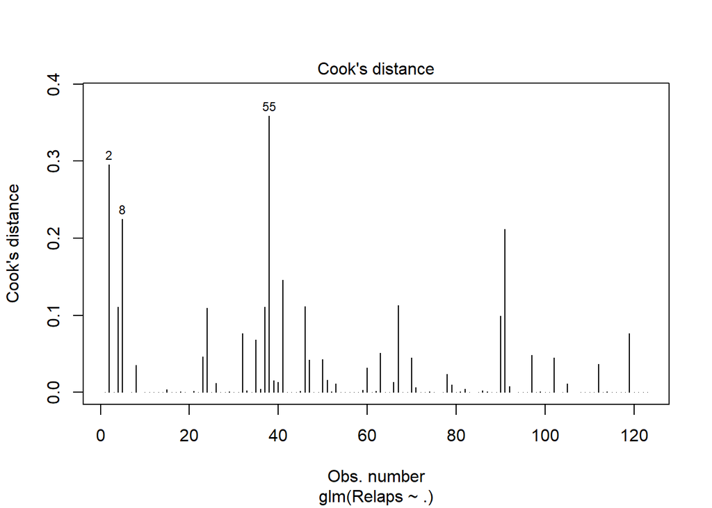

```r
plot(glm.multiple, which=4)
```

```r
#Removing outliers
train <- train[-c(2, 8, 55), ]

#Fit Logistic regression again
glm.multiple <- glm(Relaps ~ .,
                    data=train,
                    family="binomial")
summary(glm.multiple)
```

```
##
## Call:
## glm(formula = Relaps ~ ., family = "binomial", data = train)
##
## Deviance Residuals:
##      Min        1Q    Median        3Q       Max
## -2.01186  -0.06972  -0.00085   0.00001   2.00248
##
## Coefficients: (7 not defined because of singularities)
##                                   Estimate Std. Error z value Pr(>|z|)
## (Intercept)                     -2.837e+01  4.039e+04  -0.001   0.9994
## tumor_rate_percent              -9.368e-03  8.810e-02  -0.106   0.9153
## Sex1                             6.315e+00  2.989e+00   2.112   0.0347 *
## Age                             -1.787e-01  8.857e-02  -2.018   0.0436 *
## Smoking1                        -1.762e+00  2.065e+00  -0.853   0.3937
## pathS                            6.818e+00  3.665e+04   0.000   0.9999
## T_of_tumor1                      1.349e+00  2.944e+00   0.458   0.6469
## T_of_tumor2                      1.185e+01  6.299e+00   1.882   0.0599 .
## T_of_tumor3                      1.432e+01  6.796e+00   2.107   0.0351 *
## T_of_tumor4                      1.892e+01  1.104e+01   1.714   0.0865 .
## num_nodes_with_tumor            -5.452e+00  5.069e+00  -1.076   0.2821
## Staging1                        -8.404e+00  4.822e+00  -1.743   0.0813 .
## Staging2                        -6.945e+00  4.875e+00  -1.425   0.1542
## Staging3                        -2.351e+01  4.121e+03  -0.006   0.9954
## Staging4                         1.628e+00  9.543e+00   0.171   0.8645
## Staging5                        -8.479e+00  1.773e+04   0.000   0.9996
## EGFR_E19DEL                     -2.312e+01  1.820e+04  -0.001   0.9990
## EGFR_E19UNK                      2.618e+01  2.143e+04   0.001   0.9990
## EGFR_E19WT                      -2.010e+01  1.820e+04  -0.001   0.9991
## EGFR_E21UNK                             NA         NA      NA       NA
## EGFR_E21WT                       1.510e+01  6.515e+03   0.002   0.9982
## EGFR_E18UNK                             NA         NA      NA       NA
## EGFR_E18WT                       2.540e+01  1.773e+04   0.001   0.9989
## EGFR_E20INS                      3.120e+01  2.507e+04   0.001   0.9990
## EGFR_E20T790A                    5.390e+00  2.507e+04   0.000   0.9998
## EGFR_E20UNK                             NA         NA      NA       NA
## EGFR_E20WT                       2.240e+01  1.773e+04   0.001   0.9990
## KRAS_E2I36M                      3.848e+00  1.773e+04   0.000   0.9998
## KRAS_E2UNK                              NA         NA      NA       NA
## KRAS_E2WT                       -3.774e+00  3.070e+00  -1.230   0.2189
```

[output cut: 10 more lines]

```
## Station_of_Lymphnode_metastasis  2.859e-01  6.388e-01   0.448   0.6545
## Adjuvent_Chemo1                  3.331e+00  1.764e+00   1.888   0.0591 .
## Adjuvent_Radiotherapy1           8.236e+00  3.559e+00   2.314   0.0206 *
## DFS                             -1.486e-01  6.720e-02  -2.211   0.0270 *
## OS                               2.846e-02  5.027e-02   0.566   0.5713
## ---
## Signif. codes:  0 '***' 0.001 '**' 0.01 '*' 0.05 '.' 0.1 ' ' 1
##
## (Dispersion parameter for binomial family taken to be 1)
##
##     Null deviance: 134.960  on 119  degrees of freedom
## Residual deviance:  39.136  on  82  degrees of freedom
## AIC: 115.14
##
## Number of Fisher Scoring iterations: 19
```

There are some predictors that look to be significant: Sex, Age, T_of_tumor, Station_of_lymphnode_resected, Metastasis_Lymphnode, Adjuvent_Radiotherapy1 and DFS

## Variable selection via AIC

```r
step(glm.multiple)
```

```
## Start:  AIC=115.14
## Relaps ~ tumor_rate_percent + Sex + Age + Smoking + path + T_of_tumor +
##     num_nodes_with_tumor + Staging + EGFR_E19 + EGFR_E21 + EGFR_E18 +
##     EGFR_E20 + KRAS_E2 + HER2 + BRAF + ALK + Tumor_Size + Lymphnode_resected +
##     Station_of_lymphnode_resected + Metastasis_Lymphnode + Station_of_Lymphnode_metastasis +
##     Adjuvent_Chemo + Adjuvent_Radiotherapy + DFS + OS
```

[output not shown]

```
##
## Step:  AIC=115.14
## Relaps ~ tumor_rate_percent + Sex + Age + Smoking + T_of_tumor +
##     num_nodes_with_tumor + Staging + EGFR_E19 + EGFR_E21 + EGFR_E18 +
##     EGFR_E20 + KRAS_E2 + HER2 + BRAF + ALK + Tumor_Size + Lymphnode_resected +
##     Station_of_lymphnode_resected + Metastasis_Lymphnode + Station_of_Lymphnode_metastasis +
##     Adjuvent_Chemo + Adjuvent_Radiotherapy + DFS + OS
```

[output not shown]

```
##                                   Df Deviance    AIC
## - EGFR_E20                         3   40.359 110.36
## - KRAS_E2                          2   40.907 112.91
## - EGFR_E19                         2   40.985 112.98
## - HER2                             1   39.136 113.14
## - BRAF                             1   39.136 113.14
## - tumor_rate_percent               1   39.147 113.15
## - EGFR_E21                         1   39.190 113.19
## - Station_of_Lymphnode_metastasis  1   39.335 113.33
## - OS                               1   39.491 113.49
## - Staging                          5   47.678 113.68
## - Smoking                          1   39.980 113.98
## - num_nodes_with_tumor             1   40.429 114.43
## <none>                                 39.136 115.14
## - Tumor_Size                       1   41.963 115.96
## - EGFR_E18                         1   43.526 117.53
## - Metastasis_Lymphnode             1   43.970 117.97
## - ALK                              1   44.268 118.27
## - T_of_tumor                       4   50.704 118.70
## - Lymphnode_resected               1   44.988 118.99
## - Age                              1   45.193 119.19
## - Adjuvent_Chemo                   1   45.227 119.23
## - DFS                              1   49.144 123.14
## - Station_of_lymphnode_resected    1   49.382 123.38
## - Sex                              1   49.973 123.97
## - Adjuvent_Radiotherapy            1   52.569 126.57
```

```
##
## Step:  AIC=110.36
## Relaps ~ tumor_rate_percent + Sex + Age + Smoking + T_of_tumor +
##     num_nodes_with_tumor + Staging + EGFR_E19 + EGFR_E21 + EGFR_E18 +
##     KRAS_E2 + HER2 + BRAF + ALK + Tumor_Size + Lymphnode_resected +
##     Station_of_lymphnode_resected + Metastasis_Lymphnode + Station_of_Lymphnode_metastasis +
##     Adjuvent_Chemo + Adjuvent_Radiotherapy + DFS + OS
```

[output not shown]

```
##                                   Df Deviance    AIC
## - EGFR_E19                         2   41.526 107.53
## - Staging                          5   47.964 107.96
## - HER2                             1   40.359 108.36
## - tumor_rate_percent               1   40.359 108.36
## - BRAF                             1   40.359 108.36
## - EGFR_E21                         1   40.391 108.39
## - Station_of_Lymphnode_metastasis  1   40.512 108.51
## - OS                               1   40.681 108.68
## - KRAS_E2                          2   42.901 108.90
## - num_nodes_with_tumor             1   41.663 109.66
## - Smoking                          1   41.864 109.86
## <none>                                 40.359 110.36
## - Tumor_Size                       1   44.068 112.07
## - EGFR_E18                         1   44.276 112.28
## - ALK                              1   44.535 112.53
## - Metastasis_Lymphnode             1   44.613 112.61
## - Lymphnode_resected               1   45.304 113.30
## - T_of_tumor                       4   51.376 113.38
## - Age                              1   45.454 113.45
## - Adjuvent_Chemo                   1   45.629 113.63
## - Station_of_lymphnode_resected    1   49.598 117.60
## - Sex                              1   50.366 118.37
## - DFS                              1   50.730 118.73
## - Adjuvent_Radiotherapy            1   54.738 122.74
```

```
##
## Step:  AIC=107.53
## Relaps ~ tumor_rate_percent + Sex + Age + Smoking + T_of_tumor +
##     num_nodes_with_tumor + Staging + EGFR_E21 + EGFR_E18 + KRAS_E2 +
##     HER2 + BRAF + ALK + Tumor_Size + Lymphnode_resected + Station_of_lymphnode_resected +
##     Metastasis_Lymphnode + Station_of_Lymphnode_metastasis +
##     Adjuvent_Chemo + Adjuvent_Radiotherapy + DFS + OS
```

[output not shown]

```
##                                   Df Deviance    AIC
## - Staging                          5   48.755 104.75
## - HER2                             1   41.526 105.53
## - BRAF                             1   41.526 105.53
## - tumor_rate_percent               1   41.528 105.53
## - Station_of_Lymphnode_metastasis  1   41.684 105.68
## - KRAS_E2                          2   44.076 106.08
## - OS                               1   42.342 106.34
## - Smoking                          1   42.466 106.47
## - num_nodes_with_tumor             1   43.231 107.23
## <none>                                 41.526 107.53
## - EGFR_E21                         2   46.569 108.57
## - ALK                              1   44.597 108.60
## - Tumor_Size                       1   44.921 108.92
## - Metastasis_Lymphnode             1   45.007 109.01
## - EGFR_E18                         1   45.069 109.07
## - Age                              1   45.533 109.53
## - Adjuvent_Chemo                   1   45.906 109.91
## - T_of_tumor                       4   51.997 110.00
## - Lymphnode_resected               1   46.580 110.58
## - Sex                              1   50.377 114.38
## - Station_of_lymphnode_resected    1   50.748 114.75
## - DFS                              1   51.217 115.22
## - Adjuvent_Radiotherapy            1   55.450 119.45
```

```
##
## Step:  AIC=104.76
## Relaps ~ tumor_rate_percent + Sex + Age + Smoking + T_of_tumor +
##     num_nodes_with_tumor + EGFR_E21 + EGFR_E18 + KRAS_E2 + HER2 +
##     BRAF + ALK + Tumor_Size + Lymphnode_resected + Station_of_lymphnode_resected +
##     Metastasis_Lymphnode + Station_of_Lymphnode_metastasis +
##     Adjuvent_Chemo + Adjuvent_Radiotherapy + DFS + OS
```

[output not shown]

```
##                                   Df Deviance    AIC
## - KRAS_E2                          2   49.460 101.46
## - T_of_tumor                       4   54.326 102.33
## - EGFR_E21                         2   50.687 102.69
## - HER2                             1   48.755 102.75
## - BRAF                             1   48.756 102.76
## - tumor_rate_percent               1   48.763 102.76
## - Station_of_Lymphnode_metastasis  1   49.010 103.01
## - Smoking                          1   49.277 103.28
## - EGFR_E18                         1   49.995 104.00
## - OS                               1   50.153 104.15
## - ALK                              1   50.697 104.70
## - Tumor_Size                       1   50.713 104.71
## <none>                                 48.755 104.75
## - Adjuvent_Chemo                   1   50.966 104.97
## - Lymphnode_resected               1   51.295 105.30
## - Metastasis_Lymphnode             1   51.340 105.34
## - num_nodes_with_tumor             1   51.671 105.67
## - Age                              1   54.142 108.14
## - Sex                              1   55.544 109.54
## - Station_of_lymphnode_resected    1   56.004 110.00
## - Adjuvent_Radiotherapy            1   59.710 113.71
## - DFS                              1   68.749 122.75
```

```
##
## Step:  AIC=101.46
## Relaps ~ tumor_rate_percent + Sex + Age + Smoking + T_of_tumor +
##     num_nodes_with_tumor + EGFR_E21 + EGFR_E18 + HER2 + BRAF +
##     ALK + Tumor_Size + Lymphnode_resected + Station_of_lymphnode_resected +
##     Metastasis_Lymphnode + Station_of_Lymphnode_metastasis +
##     Adjuvent_Chemo + Adjuvent_Radiotherapy + DFS + OS
```

```
##                                   Df Deviance     AIC
## - T_of_tumor                       4   54.333  98.333
## - HER2                             1   49.460  99.460
## - BRAF                             1   49.461  99.461
## - tumor_rate_percent               1   49.464  99.464
## - EGFR_E21                         2   51.514  99.514
## - Station_of_Lymphnode_metastasis  1   49.755  99.755
## - Smoking                          1   50.006 100.006
## - EGFR_E18                         1   50.822 100.822
## - Tumor_Size                       1   51.050 101.050
## <none>                                 49.460 101.460
## - Adjuvent_Chemo                   1   51.538 101.538
## - OS                               1   51.884 101.884
## - num_nodes_with_tumor             1   51.957 101.957
## - ALK                              1   51.967 101.967
## - Metastasis_Lymphnode             1   52.310 102.310
## - Lymphnode_resected               1   53.028 103.028
## - Age                              1   54.804 104.804
## - Sex                              1   56.841 106.841
## - Station_of_lymphnode_resected    1   58.600 108.600
## - Adjuvent_Radiotherapy            1   60.457 110.457
## - DFS                              1   71.059 121.059
```

```
##
## Step:  AIC=98.33
## Relaps ~ tumor_rate_percent + Sex + Age + Smoking + num_nodes_with_tumor +
##     EGFR_E21 + EGFR_E18 + HER2 + BRAF + ALK + Tumor_Size + Lymphnode_resected +
##     Station_of_lymphnode_resected + Metastasis_Lymphnode + Station_of_Lymphnode_metastasis +
##     Adjuvent_Chemo + Adjuvent_Radiotherapy + DFS + OS
```

```
##                                   Df Deviance     AIC
## - HER2                             1   54.333  96.333
## - tumor_rate_percent               1   54.333  96.333
## - BRAF                             1   54.334  96.334
## - EGFR_E21                         2   56.435  96.435
## - Smoking                          1   54.541  96.541
## - EGFR_E18                         1   55.023  97.023
## - Station_of_Lymphnode_metastasis  1   55.089  97.089
## - Adjuvent_Chemo                   1   55.399  97.399
## - Tumor_Size                       1   55.767  97.767
## <none>                                 54.333  98.333
## - num_nodes_with_tumor             1   57.097  99.097
## - OS                               1   57.144  99.144
## - Metastasis_Lymphnode             1   57.414  99.414
## - ALK                              1   57.465  99.465
## - Lymphnode_resected               1   58.887 100.887
## - Sex                              1   60.446 102.446
## - Age                              1   61.188 103.188
## - Station_of_lymphnode_resected    1   64.598 106.598
## - Adjuvent_Radiotherapy            1   68.246 110.246
## - DFS                              1   76.720 118.720
##
## Step:  AIC=96.33
## Relaps ~ tumor_rate_percent + Sex + Age + Smoking + num_nodes_with_tumor +
##     EGFR_E21 + EGFR_E18 + BRAF + ALK + Tumor_Size + Lymphnode_resected +
##     Station_of_lymphnode_resected + Metastasis_Lymphnode + Station_of_Lymphnode_metastasis +
##     Adjuvent_Chemo + Adjuvent_Radiotherapy + DFS + OS
```

```
##                                   Df Deviance     AIC
## - tumor_rate_percent               1   54.333  94.333
## - BRAF                             1   54.334  94.334
## - EGFR_E21                         2   56.435  94.435
## - Smoking                          1   54.541  94.541
## - EGFR_E18                         1   55.023  95.023
## - Station_of_Lymphnode_metastasis  1   55.089  95.089
## - Adjuvent_Chemo                   1   55.399  95.399
## - Tumor_Size                       1   55.767  95.767
## <none>                                 54.333  96.333
## - num_nodes_with_tumor             1   57.097  97.097
## - OS                               1   57.144  97.144
## - Metastasis_Lymphnode             1   57.414  97.414
## - ALK                              1   57.465  97.465
## - Lymphnode_resected               1   58.887  98.887
## - Sex                              1   60.446 100.446
## - Age                              1   61.188 101.188
## - Station_of_lymphnode_resected    1   64.598 104.598
## - Adjuvent_Radiotherapy            1   68.246 108.246
## - DFS                              1   76.908 116.908
##
## Step:  AIC=94.33
## Relaps ~ Sex + Age + Smoking + num_nodes_with_tumor + EGFR_E21 +
##     EGFR_E18 + BRAF + ALK + Tumor_Size + Lymphnode_resected +
##     Station_of_lymphnode_resected + Metastasis_Lymphnode + Station_of_Lymphnode_metastasis +
##     Adjuvent_Chemo + Adjuvent_Radiotherapy + DFS + OS
```

```
##                                   Df Deviance     AIC
## - BRAF                             1   54.334  92.334
## - EGFR_E21                         2   56.502  92.502
## - Smoking                          1   54.543  92.543
## - EGFR_E18                         1   55.025  93.025
## - Station_of_Lymphnode_metastasis  1   55.093  93.093
## - Adjuvent_Chemo                   1   55.407  93.407
## - Tumor_Size                       1   55.790  93.790
## <none>                                 54.333  94.333
## - num_nodes_with_tumor             1   57.104  95.104
## - OS                               1   57.314  95.314
## - Metastasis_Lymphnode             1   57.414  95.414
## - ALK                              1   57.465  95.465
## - Lymphnode_resected               1   59.005  97.005
## - Sex                              1   60.459  98.459
## - Age                              1   61.188  99.188
## - Station_of_lymphnode_resected    1   65.883 103.883
## - Adjuvent_Radiotherapy            1   68.305 106.305
## - DFS                              1   77.608 115.608
##
## Step:  AIC=92.33
## Relaps ~ Sex + Age + Smoking + num_nodes_with_tumor + EGFR_E21 +
##     EGFR_E18 + ALK + Tumor_Size + Lymphnode_resected + Station_of_lymphnode_resected +
##     Metastasis_Lymphnode + Station_of_Lymphnode_metastasis +
##     Adjuvent_Chemo + Adjuvent_Radiotherapy + DFS + OS
##
##                                   Df Deviance     AIC
## - EGFR_E21                         2   56.503  90.503
## - Smoking                          1   54.545  90.545
## - EGFR_E18                         1   55.026  91.026
## - Station_of_Lymphnode_metastasis  1   55.094  91.094
## - Adjuvent_Chemo                   1   55.408  91.408
## - Tumor_Size                       1   55.791  91.791
## <none>                                 54.334  92.334
## - num_nodes_with_tumor             1   57.106  93.106
## - OS                               1   57.319  93.319
## - Metastasis_Lymphnode             1   57.417  93.417
## - ALK                              1   57.467  93.467
## - Lymphnode_resected               1   59.011  95.011
## - Sex                              1   60.493  96.493
```

[output cut: 133 more lines]

```
## Relaps ~ Sex + Age + num_nodes_with_tumor + Tumor_Size + Lymphnode_resected +
##     Station_of_lymphnode_resected + Adjuvent_Radiotherapy + DFS +
##     OS
##
##                                 Df Deviance     AIC
## <none>                               64.114  84.114
## - Tumor_Size                     1   66.133  84.133
## - OS                             1   67.921  85.921
## - Sex                            1   68.236  86.236
## - Lymphnode_resected             1   69.375  87.375
## - Age                            1   70.753  88.753
## - num_nodes_with_tumor           1   72.513  90.513
## - Station_of_lymphnode_resected  1   74.717  92.717
## - Adjuvent_Radiotherapy          1   78.186  96.186
## - DFS                            1   90.228 108.228
```

```
##
## Call:  glm(formula = Relaps ~ Sex + Age + num_nodes_with_tumor + Tumor_Size +
##     Lymphnode_resected + Station_of_lymphnode_resected + Adjuvent_Radiotherapy +
##     DFS + OS, family = "binomial", data = train)
##
## Coefficients:
##                   (Intercept)                           Sex1
##                       2.48917                        1.41551
##                           Age           num_nodes_with_tumor
##                      -0.09522                       -1.15493
##                    Tumor_Size             Lymphnode_resected
##                       0.23041                       -0.06995
## Station_of_lymphnode_resected         Adjuvent_Radiotherapy1
##                       0.65669                        3.49806
##                           DFS                             OS
##                      -0.12854                        0.04661
##
## Degrees of Freedom: 119 Total (i.e. Null);  110 Residual
## Null Deviance:       135
## Residual Deviance: 64.11     AIC: 84.11
```

Final model

```r
glm.multiple_final <- glm(Relaps ~  Tumor_Size +
                                    OS +
                                    Lymphnode_resected +
                                    Sex +
                                    Age +
                                    Station_of_lymphnode_resected +
                                    num_nodes_with_tumor +
                                    Adjuvent_Radiotherapy +
                                    DFS,
                        data=train,
                        family="binomial")

summary(glm.multiple_final)
```

```
##
## Call:
## glm(formula = Relaps ~ Tumor_Size + OS + Lymphnode_resected +
##     Sex + Age + Station_of_lymphnode_resected + num_nodes_with_tumor +
##     Adjuvent_Radiotherapy + DFS, family = "binomial", data = train)
##
## Deviance Residuals:
##      Min        1Q    Median        3Q       Max
## -2.29554  -0.45841  -0.08681   0.02046   2.47427
##
## Coefficients:
##                               Estimate Std. Error z value Pr(>|z|)
## (Intercept)                    2.48917    2.63295   0.945 0.344459
## Tumor_Size                     0.23041    0.16197   1.423 0.154855
## OS                             0.04661    0.02489   1.872 0.061170 .
## Lymphnode_resected            -0.06995    0.03263  -2.144 0.032052 *
## Sex1                           1.41551    0.73973   1.914 0.055679 .
## Age                           -0.09522    0.04057  -2.347 0.018930 *
## Station_of_lymphnode_resected  0.65669    0.23012   2.854 0.004321 **
## num_nodes_with_tumor          -1.15493    0.44182  -2.614 0.008948 **
## Adjuvent_Radiotherapy1         3.49806    1.05968   3.301 0.000963 ***
## DFS                           -0.12854    0.03355  -3.831 0.000128 ***
## ---
## Signif. codes:  0 '***' 0.001 '**' 0.01 '*' 0.05 '.' 0.1 ' ' 1
##
## (Dispersion parameter for binomial family taken to be 1)
##
##     Null deviance: 134.960  on 119  degrees of freedom
## Residual deviance:  64.114  on 110  degrees of freedom
## AIC: 84.114
##
## Number of Fisher Scoring iterations: 7
```

## Test model significance using likelihood ratio test

```r
#significance of full model/subset of predictors

glm.null <- glm(Relaps ~ 1,
                data=train,
                family="binomial")

# Test for significance of the full model:
anova(glm.null, glm.multiple_final, test = "LRT")
```

```
## Analysis of Deviance Table
##
## Model 1: Relaps ~ 1
## Model 2: Relaps ~ Tumor_Size + OS + Lymphnode_resected + Sex + Age + Station_of_lymphnode_resected +
##     num_nodes_with_tumor + Adjuvent_Radiotherapy + DFS
##   Resid. Df Resid. Dev Df Deviance  Pr(>Chi)
## 1       119    134.960
## 2       110     64.114  9   70.847 1.039e-11 ***
## ---
## Signif. codes:  0 '***' 0.001 '**' 0.01 '*' 0.05 '.' 0.1 ' ' 1
```

The p-val of Full model (Model 2) is almost 0. This means that there is there is an improvement on Full model over Null. Our model is significant.

## Make predictions on the training set

```r
predicted.Relaps_prob_train = predict(glm.multiple_final, newdata=train, type="response")
```

Let’s set the threshold at 0.6. Obtained probabilities over 0.6 will imply Relapse

```r
predicted.Relaps_train <- list()

for (p in predicted.Relaps_prob_train) {
  if (p > 0.6){
    predicted.Relaps_train <- append(predicted.Relaps_train, 1)
  }else{
    predicted.Relaps_train <- append(predicted.Relaps_train, 0)
  }
}
```

Calculate Model’s accuracy

```r
acc <- (train$Relaps == predicted.Relaps_train)
accuracy <- sum(acc)/length(acc)
accuracy
```

```
## [1] 0.9
```

## Make predictions on the test set

```r
predicted.Relaps_prob_test = predict(glm.multiple_final, newdata=test, type="response")
```

Let’s set the threshold at 0.6. Obtained probabilities over 0.6 will imply Relapse

```r
predicted.Relaps_test <- list()

for (p in predicted.Relaps_prob_test) {
  if (p > 0.6){
    predicted.Relaps_test <- append(predicted.Relaps_test, 1)
  }else{
    predicted.Relaps_test <- append(predicted.Relaps_test, 0)
  }
}
```

Calculate Model’s accuracy

```r
acc <- (test$Relaps == predicted.Relaps_test)
accuracy <- sum(acc)/length(acc)
accuracy
```

```
## [1] 0.8
```

Our model might be a little bit overfitted since it is achieving an accuracy of 90% in our training set and drops to 80% in the test set. However, it seems to generalize pretty well.

# 3. Bayesian Inference

```r
#Data must be numeric in nimble code
train$Relaps <- as.integer(train$Relaps ) -1
train$Sex <- as.integer(train$Sex)-1
train$Adjuvent_Radiotherapy <- as.integer(train$Adjuvent_Radiotherapy)-1

test$Relaps <- as.integer(test$Relaps ) -1
test$Sex <- as.integer(test$Sex)-1
test$Adjuvent_Radiotherapy <- as.integer(test$Adjuvent_Radiotherapy)-1
```

## Defining multiple logistic regression model

```r
y <- train$Relaps
x1 <- train$Tumor_Size
x2 <- train$OS
x3 <- train$Lymphnode_resected
x4 <- train$Sex
x5 <- train$Age
x6 <- train$Station_of_lymphnode_resected
x7 <- train$num_nodes_with_tumor
x8 <- train$Adjuvent_Radiotherapy
x9 <- train$DFS
n <- nrow(train)


y_test <- test$Relaps
x1_test <- test$Tumor_Size
x2_test <- test$OS
x3_test <- test$Lymphnode_resected
x4_test <- test$Sex
x5_test <- test$Age
x6_test <- test$Station_of_lymphnode_resected
x7_test <- test$num_nodes_with_tumor
x8_test <- test$Adjuvent_Radiotherapy
x9_test <- test$DFS
n_test <- nrow(test)

# code for the Bayesian model
code <- nimbleCode({

  alpha ~ dnorm(0, sd = 1000)
  beta1 ~ dnorm(0, sd = 1000)
  beta2 ~ dnorm(0, sd = 1000)
  beta3 ~ dnorm(0, sd = 1000)
  beta4 ~ dnorm(0, sd = 1000)
  beta5 ~ dnorm(0, sd = 1000)
  beta6 ~ dnorm(0, sd = 1000)
  beta7 ~ dnorm(0, sd = 1000)
  beta8 ~ dnorm(0, sd = 1000)
  beta9 ~ dnorm(0, sd = 1000)

  for (i in 1:n){

    eta[i] <- alpha + beta1 * x1[i] + beta2 * x2[i]+ beta3 * x3[i]+ beta4 * x4[i]+ beta5 * x5[i]+ beta6 * x6[i]+ beta7 * x7[i]+ beta8 * x8[i]+ beta9 * x9[i]
    pi[i] <- exp(eta[i]) / (1 + exp(eta[i]))
    y[i] ~ dbern(pi[i])

  }

    for (i in 1:n_test){

    eta_test[i] <- alpha + beta1 * x1_test[i] + beta2 * x2_test[i]+ beta3 * x3_test[i]+ beta4 * x4_test[i]+ beta5 * x5_test[i]+ beta6 * x6_test[i]+ beta7 * x7_test[i]+ beta8 * x8_test[i]+ beta9 * x9_test[i]
    pi_test[i] <- exp(eta_test[i]) / (1 + exp(eta_test[i]))
    y_test[i] ~ dbern(pi_test[i])

  }


  for (i in 1:n){

    eta_train[i] <- alpha + beta1 * x1[i] + beta2 * x2[i]+ beta3 * x3[i]+ beta4 * x4[i]+ beta5 * x5[i]+ beta6 * x6[i]+ beta7 * x7[i]+ beta8 * x8[i]+ beta9 * x9[i]
    pi_train[i] <- exp(eta_train[i]) / (1 + exp(eta_train[i]))
    y_train[i] ~ dbern(pi_train[i])

  }


})

constants <- list(n = n, x1 = x1,x2 = x2,x3=x3,x4=x4,x5=x5,x6=x6,x7=x7,x8=x8,x9=x9,n_test = n_test, x1_test = x1_test,x2_test = x2_test,x3_test=x3_test,x4_test=x4_test,x5_test=x5_test,x6_test=x6_test,x7_test=x7_test,x8_test=x8_test,x9_test=x9_test)
data <- list(y = y)
initial <- list(alpha = mean(y), beta1 = 0, beta2 = 0, beta3 = 0, beta4 = 0, beta5=0, beta6=0, beta7=0, beta8=0, beta9=0)
Rmodel <- nimbleModel(code, constants, data, initial)
```

```
## Defining model
```

```
## Building model
```

```
## Setting data and initial values
```

```
## Running calculate on model
##   [Note] Any error reports that follow may simply reflect missing values in model variables.
```

```
## Checking model sizes and dimensions
```

```
##   [Note] This model is not fully initialized. This is not an error.
##          To see which variables are not initialized, use model$initializeInfo().
##          For more information on model initialization, see help(modelInitialization).
```

```r
conf <- configureMCMC(Rmodel)
```

```
## ===== Monitors =====
## thin = 1: alpha, beta1, beta2, beta3, beta4, beta5, beta6, beta7, beta8, beta9
## ===== Samplers =====
## RW sampler (10)
##   - alpha
##   - beta1
##   - beta2
##   - beta3
##   - beta4
##   - beta5
##   - beta6
##   - beta7
##   - beta8
##   - beta9
## posterior_predictive sampler (170)
##   - y_test[]  (50 elements)
##   - y_train[]  (120 elements)
```

```r
## Add a monitor for the sampled alpha[j]'s:
conf$addMonitors("y_test")
```

```
## thin = 1: alpha, beta1, beta2, beta3, beta4, beta5, beta6, beta7, beta8, beta9, y_test
```

```r
conf$addMonitors("y_train")
```

```
## thin = 1: alpha, beta1, beta2, beta3, beta4, beta5, beta6, beta7, beta8, beta9, y_test, y_train
```

```r
conf$getMonitors()
```

```
##  [1] "alpha"   "beta1"   "beta2"   "beta3"   "beta4"   "beta5"   "beta6"
##  [8] "beta7"   "beta8"   "beta9"   "y_test"  "y_train"
```

```r
Rmcmc <- buildMCMC(conf)
Cmodel <- compileNimble(Rmodel)
```

```
## Compiling
##   [Note] This may take a minute.
##   [Note] Use 'showCompilerOutput = TRUE' to see C++ compilation details.
```

```r
Cmcmc <- compileNimble(Rmcmc, project = Rmodel)
```

```
## Compiling
##   [Note] This may take a minute.
##   [Note] Use 'showCompilerOutput = TRUE' to see C++ compilation details.
```

## Running MCMC

```r
set.seed(0)
results <- runMCMC(Cmcmc, niter = 11000, nburnin = 1000, samples=TRUE, summary=TRUE)
```

```
## running chain 1...
```

```
## |-------------|-------------|-------------|-------------|
## |-------------------------------------------------------|
```

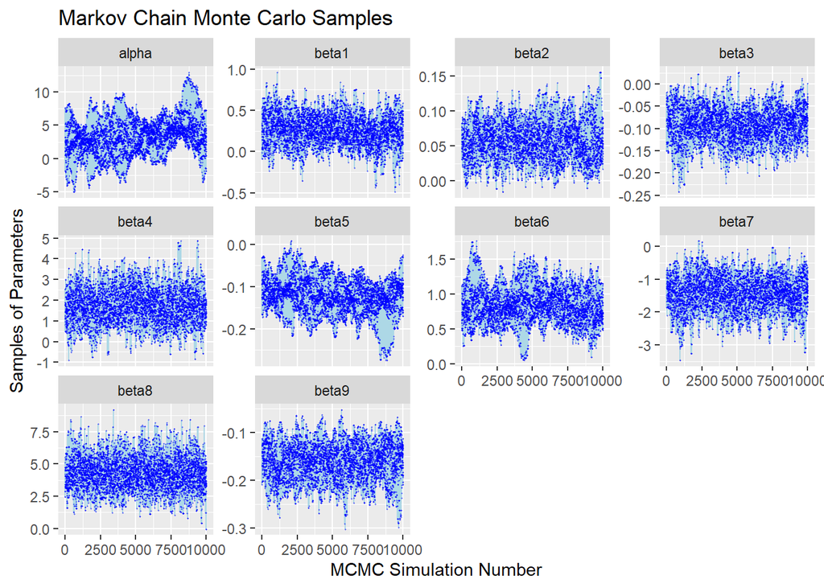

```r
## Plot Markov Chains:
plotdata <- as_tibble(results$samples) %>%
  pivot_longer(cols=c("alpha","beta1","beta2","beta3","beta4","beta5","beta6","beta7","beta8","beta9"), names_to="Parameter", values_to="Values") %>%
  add_column(Sequence = rep(1:nrow(results$samples),10))
ggplot(data=plotdata, aes(x=Sequence, y=Values)) +
  geom_line(col="lightblue") +
  geom_point(col="blue", pch=16, size=0.2, alpha=0.5) +
  facet_wrap(vars(Parameter), nrow=3, scale="free_y") +
  labs(x = "MCMC Simulation Number",
       y = "Samples of Parameters",
       title = "Markov Chain Monte Carlo Samples")
```

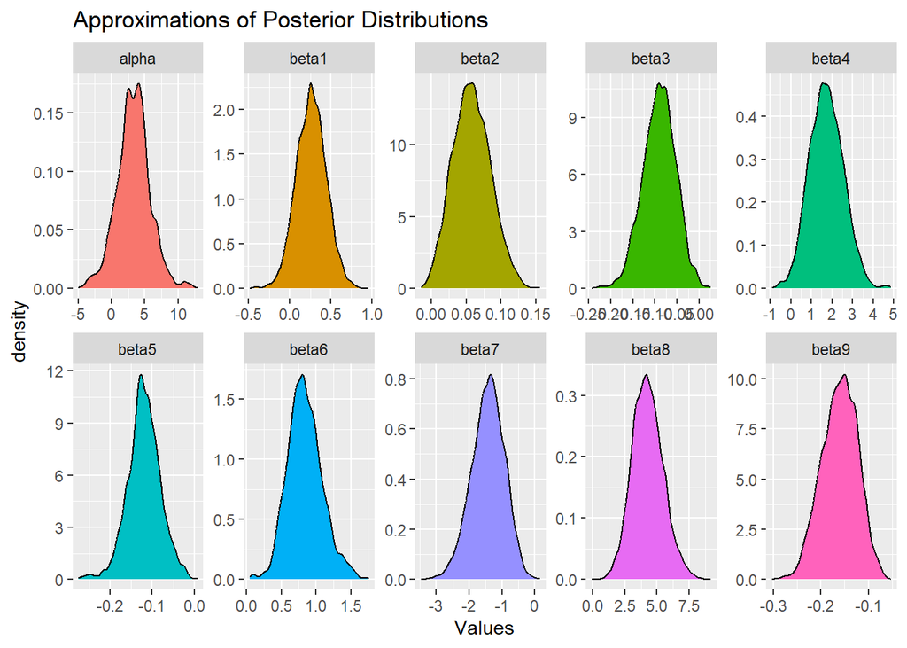

```r
## Plot Density Estimates:
ggplot(data=plotdata, aes(x=Values, fill=Parameter)) +
  geom_density(color="black") +
  facet_wrap(vars(Parameter), nrow=2, scale="free") +
  labs(title="Approximations of Posterior Distributions") +
  theme(legend.position="none")
```

Comparing the coefficients between regular logistic regression and Bayesian

```r
summary(glm.multiple_final)$coef
```

```
##                                  Estimate Std. Error    z value     Pr(>|z|)
## (Intercept)                    2.48917014 2.63295098  0.9453918 0.3444589108
## Tumor_Size                     0.23041286 0.16196699  1.4225915 0.1548546197
## OS                             0.04660682 0.02489332  1.8722619 0.0611703792
## Lymphnode_resected            -0.06994971 0.03262938 -2.1437647 0.0320517488
## Sex1                           1.41551061 0.73973429  1.9135393 0.0556790526
## Age                           -0.09522260 0.04057373 -2.3469030 0.0189301808
## Station_of_lymphnode_resected  0.65668768 0.23011533  2.8537329 0.0043208848
## num_nodes_with_tumor          -1.15493471 0.44182030 -2.6140372 0.0089479287
## Adjuvent_Radiotherapy1         3.49806225 1.05968394  3.3010430 0.0009632612
## DFS                           -0.12853604 0.03354949 -3.8312373 0.0001275005
```

```r
results$summary[1:10, ]
```

```
##              Mean      Median    St.Dev.    95%CI_low   95%CI_upp
## alpha  3.30225323  3.34102057 2.49687619 -1.864560683  8.36194332
## beta1  0.26240979  0.26302995 0.18103890 -0.087677831  0.61712700
## beta2  0.05769802  0.05705620 0.02690738  0.007874383  0.11217909
## beta3 -0.09041589 -0.08936033 0.03718040 -0.164479200 -0.02197973
## beta4  1.73010566  1.70994077 0.82167792  0.188661583  3.35794956
## beta5 -0.11979324 -0.12005308 0.03910067 -0.199180729 -0.04258829
## beta6  0.84056951  0.82479270 0.24967096  0.402588306  1.39332579
## beta7 -1.42636591 -1.40232500 0.50190584 -2.466466900 -0.51213332
## beta8  4.27463129  4.22414570 1.20291900  2.011439472  6.82985616
## beta9 -0.16066051 -0.15893446 0.03754141 -0.235162495 -0.09232736
```

The coefficients are different between the regular and Bayesian logistic models, but they are roughly similar.

## Making predictions with Bayesian approach

```r
#predicted probabilities
test_prob <- colMeans(results$samples)[11:60]
train_prob <- colMeans(results$samples)[61:180]
```

Using previous approach for making predictions (threshold = 0.6)

```r
train_pred <- list()

for (p in train_prob) {
  if (p > 0.6){
    train_pred <- append(train_pred, 1)
  }else{
    train_pred <- append(train_pred, 0)
  }
}
```

Calculate Model’s accuracy on Train set

```r
acc <- (train$Relaps == train_pred)
accuracy <- sum(acc)/length(acc)
accuracy
```

```
## [1] 0.9
```

```r
test_pred <- list()

for (p in test_prob) {
  if (p > 0.6){
    test_pred <- append(test_pred, 1)
  }else{
    test_pred <- append(test_pred, 0)
  }
}
```

Calculate Model’s accuracy on Test set

```r
acc <- (test$Relaps == test_pred)
accuracy <- sum(acc)/length(acc)
accuracy
```

```
## [1] 0.8
```

```r
identical(train_pred,predicted.Relaps_train)
```

```
## [1] TRUE
```

```r
identical(test_pred,predicted.Relaps_test)
```

```
## [1] TRUE
```

The Bayesian approach has identical performance and predictions (at a threshold of 0.6) as regular logistic regression.